# FLR toolset for evaluating recovery plans for ICES WKREBUILD2

Iago MOSQUEIRA (WMR) <iago.mosqueira@wur.nl

03 november 2023

# Installation

The latest version of the required FLR packages, and all their dependencies, can be installed from the [FLR R-universe page](https://flr.r-universe.dev) by calling:

```r
install.packages("icesTAF")

install.packages(icesTAF::deps(), repos=c(
  FLR="https://flr.r-universe.dev",
  CRAN="https://cloud.r-project.org/"))
```

They can also be installed from the source code in the [FLR github repositories](https://github.com/flr) by calling

```r
remotes::install_github(paste0("flr/", c("FLCore", "ggplotFL", "FLFishery", "FLasher", "FLSRTMB", "mse", "mseviz")))
```

# Setup

Updates on the progress of the analysis can be obtained through the [progressr](https://progressr.futureverse.org/) package, which is already available as a dependency to mse. Please use the following command to request all progress output to be shown. This applies to calls to functions *mp*, *mps* and *bootstrapSR*.

```r
handlers(global=TRUE)
```

A parallel backend can be specified, setup using any of those that work with the ‘future’ package, each scenario will be run on separate cores or nodes. The example above, executed over 5 cores on a laptop computer, took 3 minutes to finalise.

# TAF repository

## bootstrap/initial

The essential inputs for the analysis include the result of the stock assessment model fit and the current set of reference points.

For example, `bootstrap/initial/data/sol274.rda` contains the following objects:

- `run`: The latest AAP stock assessment for sol.27.4 (WGNSSK 2023), as an object or class `FLStock`. The object does not reflect the WGNSSK 2023 sol.27.4 assessment, as it has been artificially depleted for demonstration purposes.
- `refpts`: An object of class `FLPar` containing the reference points, biological and operational, calculated for this stock in the last benchmark (ICES, 2020).

Uncertainty in past dynamics and initial conditions might have been already quantified, for example by employing the McMC sampling procedure available in the stock assessment model, by bootstrap of model inputs, or through a ensemble of model fits. If that is the case, the conditioning steps in `data.R` should be adapted accordingly.

# OM conditioning, `data.R`

From the stock assessment run, or a set of chosen ensemble runs, an operating model (OM) is to be constructed to evaluate the alternative advice rules by introducing some of the potential uncertainty in future dynamics, in this case in recruitment.

First, one or multiple stock-recruitment relationships are fitted to the data, and then to bootstrapped series of the stock-recruits pairs, following the approach applied in ICES to category 1 stocks [@ICESrefpts_2022].

```r
fits <- srrTMB(as.FLSRs(run, models=c("bevholt", "segreg")),
  spr0=mean(spr0y(run)))

srpars <- bootstrapSR(run, iters=it,
  models=c("bevholt", "segreg"), method="best")
```

An `FLom` object can now be assembled. This is the *FLR* representation of an operating model for a single stock and fishery, and contains all that is required for projecting the stock forward under different management regimes.

```r
om <- FLom(stock=propagate(run, it), refpts=refpts, model='mixedsrr',
  params=srpars, deviances=srdevs)
```

This call builds the object with the initial population (*run*), propagated or replicated for the desired number of iterations (*it*), the matching biological reference points (*refpts*), the SRR to be applied and the set of parameters obtained from the bootstrap step (*model* and *params*), and the deviances to apply over the future recruitment estimates. These have been generated in this case following a log-normal distribution, with variance and autocorrelation computed from the bootstrap analysis.

```r
srdevs <- rlnormar1(sdlog=srpars$sigmaR, rho=srpars$rho, years=seq(dy, fy))
```

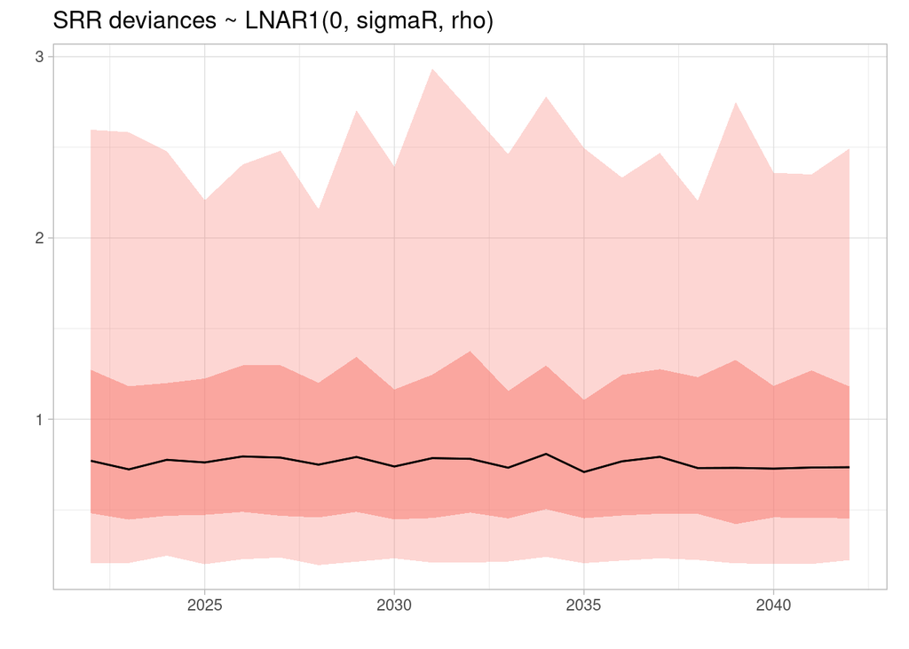

The OM can now be extended until the final year (*fy*). The default call to `fwdWindow()` sets both future biology (weights, maturity and natural mortality) and fishery dynamics (selectivity and discards ratio) to remain as the average of the last 3 years in the model run

```r
om <- fwdWindow(om, end=fy)
```

Other options exist for determining future values and patterns in any assumed quantity. For example, values can be resampled from a number of recent years, or different number of years can be used to compute the future average values. For example, this alternative call found the *trove.R* file, uses an averages of the last five years, except for weights-at-age, in stock, landings, discards and catch, which are instead resampled over the same period. Future values in the *om* object can also be modified directly.

```r
om <- fwdWindow(window(om, end=2023), end=fy, nsq=5,
  fun=c("mean", wt="sample"))
```

The following MP runs do not include any error or bias in observations (catch and biological sampling), as a shortcut to the stock assessment is being used to obtain the stock status metrics. A full-feedback evaluation of an MP, in which the stock assessment or any status indicator is computed from catch, biology or survey data, an object of class `FLoem` can be constructed for this purpose. The class contains a method to be applied to observe the OM, add any specified error or bias, and merge those with past observations.

Implementation error can also be incorporated in the evaluation of MPs. An object is assembled containing the choice of implementation dynamics and the levels of error. An approximate 10% error in implementation can be added, for example, through a LN(0, 0.10) distribution as follows.

```r
iem <- FLiem(method=noise.iem,
  args=list(noise=rlnorm(500, rec(om) %=% 0, 0.1)))
```

# Evaluation of recovery rules, `model.R`

To construct a baseline level for comparing the candidate recovery procedures, a projection under a full fishery closure ($\bar{F} = 0$) can be carried out.

```r
runf0 <- fwd(om, control=fwdControl(year=seq(2024, 2042), quant="fbar",
  value=0))
```

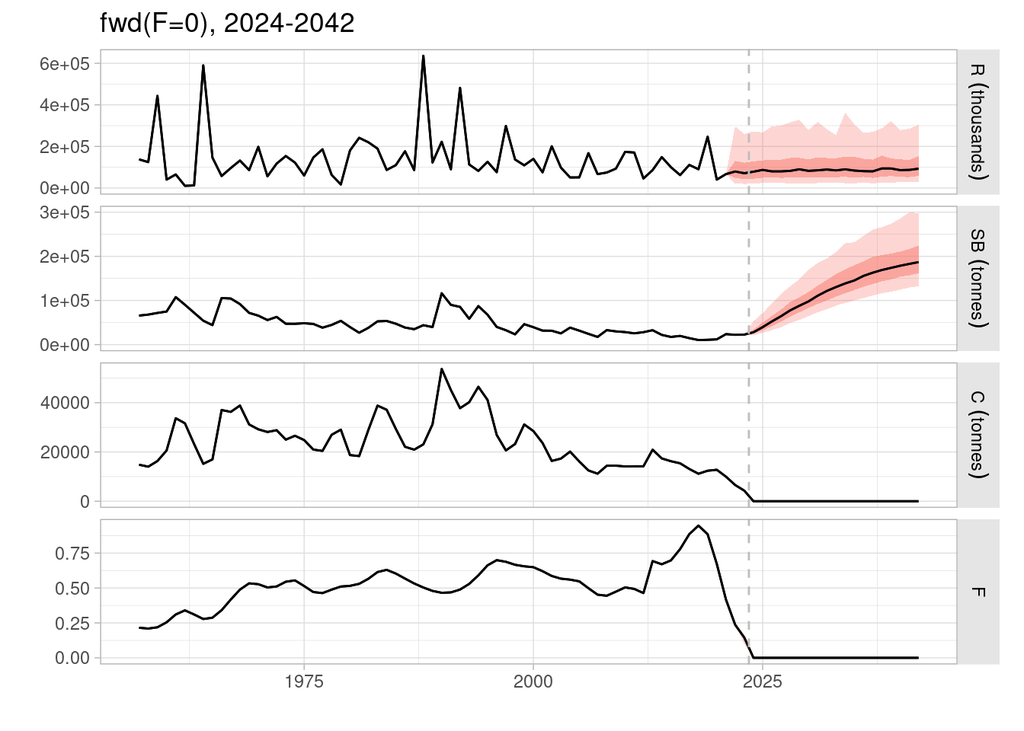

Recovery rules, or any other management procedure (MP), are composed of a number of steps for which modules can be specified in an object of the `mpCtrl` class. The rules under analysis for WKREBUILD2 consist of three elements:

1. An estimation method (*est*): a shortcut module substitutes the stock assessment method, with added deviances in the estimate of stock status (`SSBdevs`).
2. A Harvest Control Rule (*hcr*): a hockeystick HCR with four variables (limit, minimum, target and trigger) is set up, using SSB as input and F as output.
3. An implementation system (*isys*): this step implements the short-term forecast used to convert the F given by the HCR into a TAC value to be used on the advice year. The method sets future biology and selectivity to match the recent (3 years) averages, computes past observed recruitment to obtain a geometric mean to apply in the projection, adds deviances to the fishing mortalities applied to the stock, and carries out the forecast to obtain the corresponding catch level. The intermediate year assumption is that of fishing mortality being equal to the last observed year, but the alternative assumption of catch equal to the set TAC could be added if necessary.

These three steps are specified in a control structure, as follows:

```r
arule <- mpCtrl(list(
  # shortcut.sa + SSBdevs
  est = mseCtrl(method=shortcut.sa,
    args=list(SSBdevs=sdevs$SSB)),
  # hockeystick as ICES
  hcr = mseCtrl(method=hockeystick.hcr,
    args=list(lim=0, trigger=refpts(om)$Btrigger, target=refpts(om)$Fmsy,
    min=0, metric="ssb", output="fbar")),
  #
  isys = mseCtrl(method=tac.is,
    args=list(recyrs=30, fmin=0, Fdevs=sdevs$Fdevs))))
```

This `mpCtrl` object implements the ICES advice rule with biomass trigger and F target levels taken from the *eqsim*-based calculations of the last benchmark for this stock.

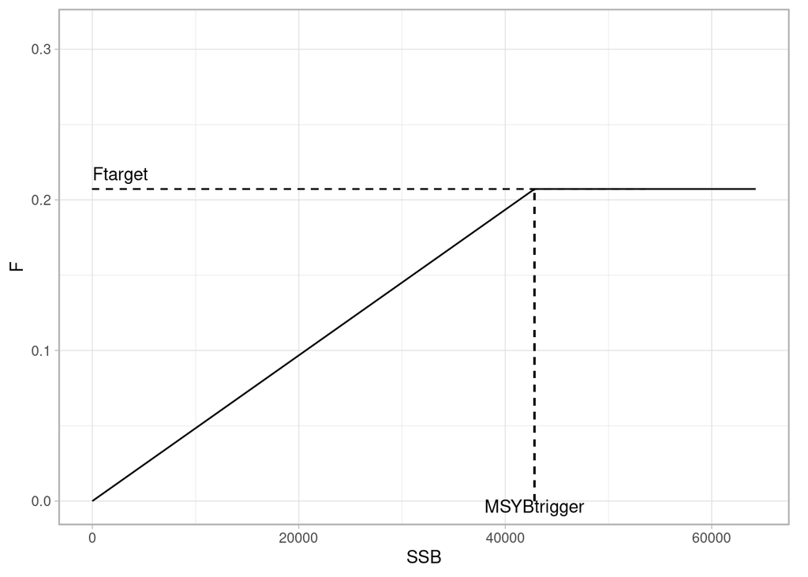

```r
plot_hockeystick.hcr(arule$hcr, labels=c(trigger="MSYBtrigger", limit="",
  min="", target="Ftarget")) + xlab("SSB") + ylab("F")
```

Applying the MP specified by such a control structure requires a call to the *mp()* function with the OM, OEM and control objects as main arguments. Only one extra argument is required, a list containing at least the starting year of the simulation (*iy*). By default the simulation will run to the last year of the ‘om’ object (*fy*), on an annual basis (*frq*), and with one year of lag in both data (*data_lag*) and decision implementation (*management_lag*). Running an MP that sets advice for a three-year period, for example, only requires passing the corresponding value in the list, 2023, 3.

```r
mseargs <- list(iy=2023, fy=2042, data_lag=1, management_lag=1, frq=1)
```

We now proceed to run the MP applying on the ICES advice rule and a shortcut approach to the stock assessment.

```r
advice <- mp(om, iem=iem, ctrl=arule, args=mseargs)
```

```r
tracking(advice)[c('SB.om', 'met.hcr', 'decision.hcr', 'hcr',
  'fbar.isys', 'isys'), ac(2024:2026)]
```

[output not shown]

A set of runs can now be conducted in which the standard advice rule is modified in various ways. For example, a range of values are explored for the *lim* argument: the level of the input metric (SSB in this case) at which the output (F) is set to the *min* value. Five between 0 and the value of *Blim* for sol.27.4 were chosen in this example. To run these alternative MPs, the ‘mps’ function takes the same arguments as a call for a single MP, but also a list of alternative values for one of more of the HCR arguments, for example

```r
limopts <- mps(om, ctrl=arule, args=mseargs,
  hcr=list(lim=seq(0, c(refpts(om)$Blim), length=5)))
```

Combinations of alternative arguments can be specified more easily by calling the `combinations` function, for example

```r
opts <- combinations(
  lim=seq(0, c(refpts(om)$Btrigger) * 0.50, length=3),
  min=c(0, 0.05))
```

This list can now be used in the call to `mps()` to evaluate the resulting six MPs.

```r
plans <- mps(om, ctrl=arule, args=mseargs, hcr=opts)
```

The returned object is a list containing one `FLmse` object for each alternative HCR formulation, which we can plot preceded by the OM

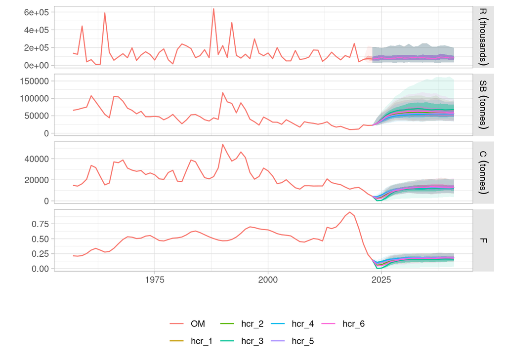

```r
plot(om, plans)
```

# Computing and summarizing performance, `output.R`

The performance of alternative MPs is evaluated against a set of performance statistics and for one or more time frames, either continuous or across years.

- *PBlim*, the probability that spawner biomass is above $B_{lim}$.
- *PBtrigger*, the probability that spawner biomass is above $B_{trigger}$.
- *C*, Mean catch per year.
- *cvC*, CV of catch per year.

Others are to be calculated for a period, or different periods, of years, which are specified in the call to `performance()`. Those currently defined are:

- *C*, Mean catch over years.
- *AVVC*, Average annual variability in catch.
- *IACC*, Percentage inter-annual change in catch.
- *risk2*, ICES Risk 2, probability that spawner biomass is above $B_{lim}$ once.
- *firstyear*, First year in which $P(B/B_{lim}) >= 0.95$.

A number of performance statistics are available in the `mse` package, each of them defined by formula, a name and a description.

```r
data(statistics)

names(statistics)
```

```
#>  [1] "SB0"     "minSB0"  "SBMSY"   "Ftarget" "FMSY"    "green"   "red"     "PSBMSY"  "PSBlim"  "PSB20B0" "risk1"   "risk2"   "risk3"   "C"       "CMSY"    "AAVC"    "IACC"
#> [18] "PC0"
```

```r
statistics$risk2
```

```
#> [[1]]
#> ~yearMeans(iterMeans(((SB/SBlim) < 1) > 0))
#>
#> $name
#> [1] "once(P(SB<B[limit]))"
#>
#> $desc
#> [1] "ICES Risk 2, probability that spawner biomass is above Blim once"
```

Performance across all MP runs can be computed by specifying what statistics to use and over what time period. The *years* argument can set as a vector

```r
performance(c(plans, F0=runf0), statistics=annualstats, years=2023:2041)
```

```
#>         mp statistic year data iter    name                 desc
#>   1: hcr_1         C 2023 4289    1 mean(C)  Mean catch per year
#>   2: hcr_1         C 2024 3591    1 mean(C)  Mean catch per year
#>   3: hcr_1         C 2025 5139    1 mean(C)  Mean catch per year
#>   4: hcr_1         C 2026 7576    1 mean(C)  Mean catch per year
#>   5: hcr_1         C 2027 9433    1 mean(C)  Mean catch per year
#>  ---
#> 528:    F0       cvC 2037  NaN    1   cv(C) CV of catch per year
#> 529:    F0       cvC 2038  NaN    1   cv(C) CV of catch per year
#> 530:    F0       cvC 2039  NaN    1   cv(C) CV of catch per year
#> 531:    F0       cvC 2040  NaN    1   cv(C) CV of catch per year
#> 532:    F0       cvC 2041  NaN    1   cv(C) CV of catch per year
```

in which case the statistics are computed annually. Or it could be of class *list*, and the statistics will be applied over the whole period or periods

```r
performance(c(plans, F0=runf0), statistics=fullstats,
  years=list(short=2023:2026, long=2023:2041))
```

```
#>           mp statistic  year      data iter                 name                                                             desc
#>     1: hcr_1      AAVC  long 2.278e-01    1               AAV(C)                              Average annual variability in catch
#>     2: hcr_1      AAVC  long 1.619e-01    2               AAV(C)                              Average annual variability in catch
#>     3: hcr_1      AAVC  long 1.697e-01    3               AAV(C)                              Average annual variability in catch
#>     4: hcr_1      AAVC  long 1.451e-01    4               AAV(C)                              Average annual variability in catch
#>     5: hcr_1      AAVC  long 1.632e-01    5               AAV(C)                              Average annual variability in catch
#>    ---
#> 21024:    F0      IACC short 1.000e+02  500               IAC(C)                          Percentage inter-annual change in catch
#> 21025:    F0 firstyear  long 2.026e+03    1             recovery                          First year in which P(SB/SBlim) >= 0.95
#> 21026:    F0 firstyear short 2.026e+03    1             recovery                          First year in which P(SB/SBlim) >= 0.95
#> 21027:    F0     risk2  long 9.747e-02    1 once(P(SB<B[limit])) ICES Risk 2, probability that spawner biomass is above Blim once
#> 21028:    F0     risk2 short 4.615e-01    1 once(P(SB<B[limit])) ICES Risk 2, probability that spawner biomass is above Blim once
```

Note how the initial projection with no catches, *runF0*, gets added to the set of MPs being compared.

Additional performance statistics can be defined as a list containing a formula to compute it, a name, and a description. Formulas can make use or existing or new functions, and refer to either *metrics*, functions that return summary values computed from the OM, or the names of reference points stored in the *refpts* slot. For example, the *risk1* statistics is defined by the formula `~yearMeans(iterMeans((SB/SBlim) < 1))`, where `SB` refers to the metric defined to call the `ssb` method, while `SBlim` is one of the reference points defined in the `FLom` object.

# Generating graphical outputs, `report.R`

```
#> Loading objects:
#>   perf_year
#>   perf
#>   tables
```

A number of plot functions are available in the mseviz package for displaying and comparing the results of the MP runs and the performance statistics. For example boxplots of each multi-annual performance metric by MP can be displayed by calling

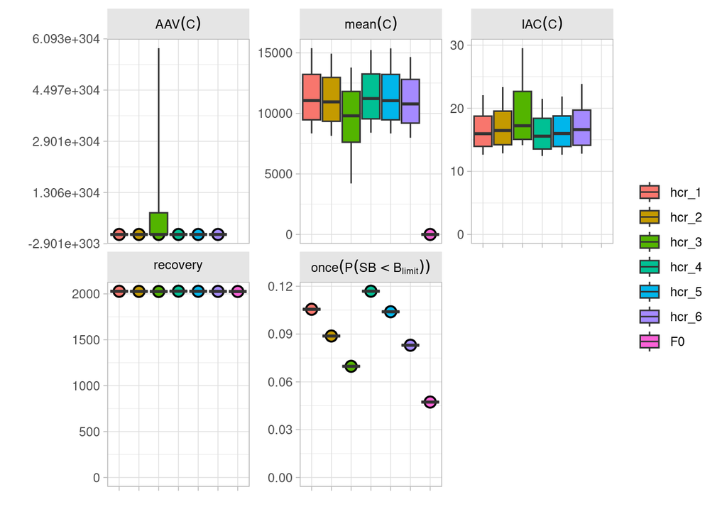

```r
plotBPs(perf[year=='all']) + ylim(c(0, NA))
```

The `plotOMruns` function present a time series of a single metric (e.g. `ssb`) for the OM, in the top panel, and the various MPs below it.

```r
plotOMruns(window(ssb(om), end=2023), FLQuants(lapply(plans, ssb))) +
  ggtitle("SSB (t)")
```

[output not shown]

# Specific functions, `utilities.R`

- A number of functions are currently defined in the `utilities.R` file. any function of general application will be incorporated into any of the FLR packages being used. ICES-specific functions should be integrated into an MSE-related package, or on any of the existing ICES R packages, if suitable.

# Alternative steps, `trove.R`

# Reproducibility and version control

Once an analysis is running, the mechanisms of TAF should be used to keep track of what package versions were used. This ensures the reproducibility of the whole analysis.

If packages have been installed from the [FLR github](https://github.com/flr) repositories, the `bootstrap/SOFTWARE.bib` file storing all version info can be created by calling

```r
flrpkgs <- c("FLCore", "FLFishery", "FLasher", "mse", "ggplotFL",
  "mseviz", "FLSRTMB")

icesTAF::draft.software(flrpkgs, file=TRUE)
```

If packages have been installed from [r-universe](https://flr.r-universe.dev), we can add the version information using the following (experimental) code.

```r
flrpkgs <- c("FLCore", "FLFishery", "FLasher", "mse", "ggplotFL",
  "mseviz", "FLSRTMB")

bib <- lapply(flrpkgs, function(x) {

  bib <- draft.software(x)

  return(sub('  source  = \\{\\},', paste0("  source = \\{flr/", x, "@", packageDescription(x)$RemoteSha, "\\},"), bib))
  }
)

file <- file.path(boot.dir(), "SOFTWARE.bib")

write(unlist(bib), file=file, append=FALSE)
```

The `SOFTWARE.bib` file now contains the github commit references to the package versions that were installed via the [FLR r-universe](https://flr.r-universe.dev) repository. A call to `icesTAF::taf.bootstrap(software=TRUE)` would download and install those precise versions in the `bootstrap` folder. The file will also be used by the TAF server in ICES to use the same versions when running the code.

# Asking for help

To report bugs or make suggestions regarding this example, please use the [repository issues](https://github.com/ices-tools-prod/WKREBUILD_toolset/issues?q=is%3Aissue+is%3Aopen+sort%3Aupdated-desc). If the problem is with code in any one particular package, please use the corresponding issue page for its repository at the [FLR github project](https://github.com/flr/).